# IFN702: Educational Data Mining project

# Students have the higher class the more raised hands.

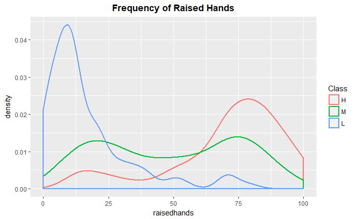

```r
ggplot(data = E, aes(x = raisedhands, color = Class)) + geom_density(size=1) + ggtitle("Frequency of Raised Hands") +theme(plot.title = element_text(hjust = 0.5, lineheight = 0.8, face = "bold"))
```

# Most of the high class students raised hands many times, most of the low class students raised hands very few times.

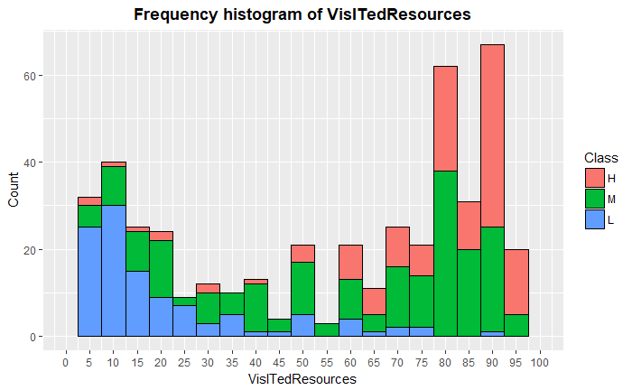

```r
ggplot(E, aes(x = VisITedResources, fill = Class)) +
        geom_histogram( binwidth = 5, colour = "black") +
        scale_x_continuous(name = "VisITedResources",
                           breaks = seq(0, 100, 5),
                           limits=c(0, 100)) +
        scale_y_continuous(name = "Count") +
        ggtitle("Frequency histogram of VisITedResources")+theme(plot.title = element_text(hjust = 0.5, lineheight = 0.8, face = "bold"))
```

# Students who have the higher class visited the resources more times.

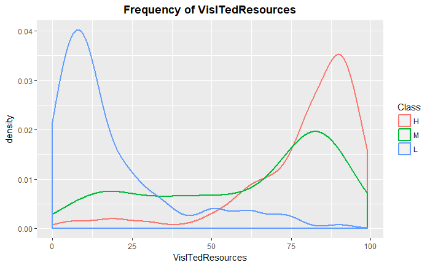

```r
ggplot(data = E, aes(x = VisITedResources, color = Class)) + geom_density(size=1) + ggtitle("Frequency of VisITedResources") +theme(plot.title = element_text(hjust = 0.5, lineheight = 0.8, face = "bold"))
```

# Most of the students with high class visited the resources many times, most of the students with low class visited the resources very few times.

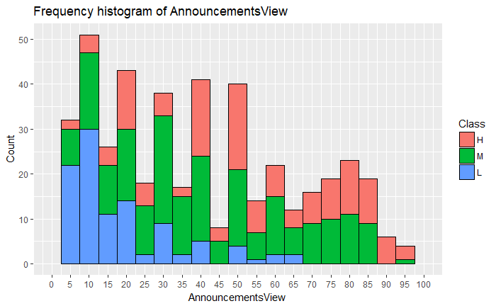

```r
ggplot(E, aes(x = AnnouncementsView, fill = Class)) +
        geom_histogram( binwidth = 5, colour = "black") +
        scale_x_continuous(name = "AnnouncementsView",
                           breaks = seq(0, 100, 5),
                           limits=c(0, 100)) +
        scale_y_continuous(name = "Count") +
        ggtitle("Frequency histogram of AnnouncementsView")
```

# Students who have the higher class viewed the announcements more times.

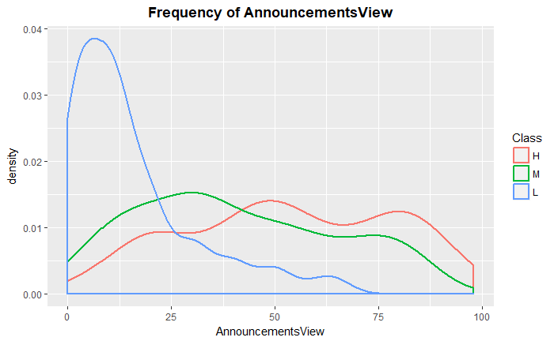

```r
ggplot(data = E, aes(x = AnnouncementsView, color = Class)) + geom_density(size=1) + ggtitle("Frequency of AnnouncementsView") +theme(plot.title = element_text(hjust = 0.5, lineheight = 0.8, face = "bold"))
```

# Most of the students with high class viewed the announcements many times, most of the students with low class viewed the announcements very few times. But the differences between students with high class and medium class is not very obvious

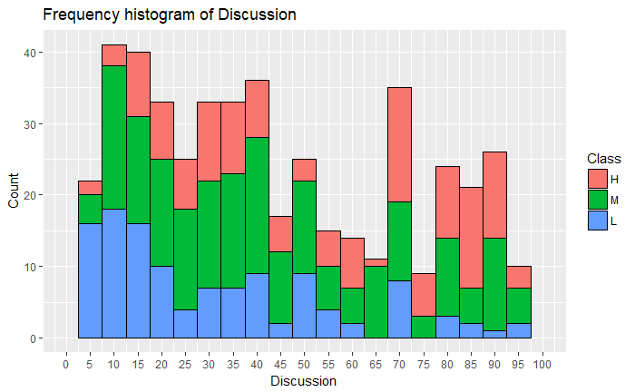

```r
ggplot(E, aes(x = Discussion, fill = Class)) +
        geom_histogram(binwidth = 5, colour = "black") +
        scale_x_continuous(name = "Discussion",
                           breaks = seq(0, 100, 5),
                           limits=c(0, 100)) +
        scale_y_continuous(name = "Count") +
        ggtitle("Frequency histogram of Discussion")
```

# Students who have the higher class discussed more times.

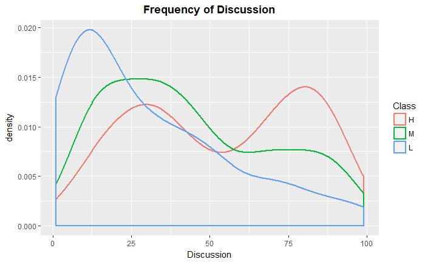

```r
ggplot(data = E, aes(x = Discussion, color = Class)) + geom_density(size=1) + ggtitle("Frequency of Discussion") +theme(plot.title = element_text(hjust = 0.5, lineheight = 0.8, face = "bold"))
```

# Most of the students with high class discussed many times, most of the students with low class discussed very few times.

# Summary of Task 1.3: From the exploration of the numerical feature values, we have the following findings:

# 1 .Students who have the higher class raised hands, visited resource, viewd announcements and discussed more times.

# 2. Most of the students with high class have many times of raised hands, visited resource, viewed announcements and discussion, most of the students with low class raised hands, visited resource, viewed announcements and discussed few times.

# 3. There are some little differences in the density curve, especially in the announcement view and discussion.

# Task 2. Exploration of the relationships between different features of the students’ academic performance datasets

# Class and the numerial features

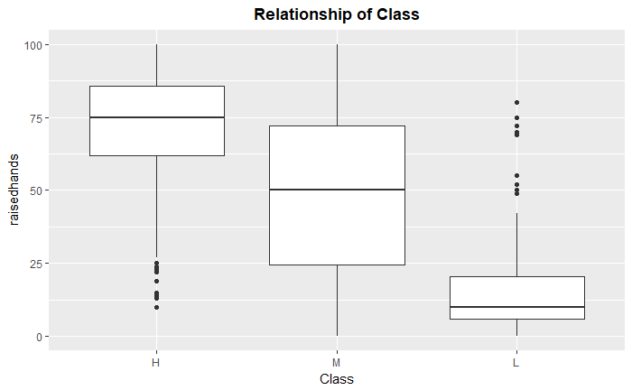

```r
ggplot(data = E, aes(x = Class, y = raisedhands)) + geom_boxplot()+ ggtitle("Relationship of Class") +theme(plot.title = element_text(hjust = 0.5, lineheight = 0.8, face = "bold"))
```

# The higher class the higher times of raising hands

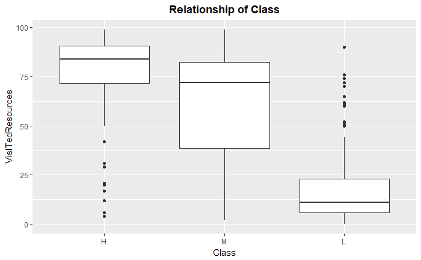

```r
ggplot(data = E, aes(x = Class, y = VisITedResources)) + geom_boxplot()+ ggtitle("Relationship of Class") +theme(plot.title = element_text(hjust = 0.5, lineheight = 0.8, face = "bold"))
```

# The higher class the higher times of visiting resources

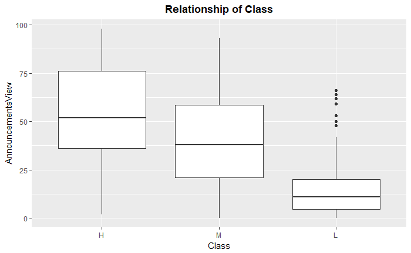

```r
ggplot(data = E, aes(x = Class, y = AnnouncementsView)) + geom_boxplot()+ ggtitle("Relationship of Class") +theme(plot.title = element_text(hjust = 0.5, lineheight = 0.8, face = "bold"))
```

# The higher class the higher times of viewing announcements

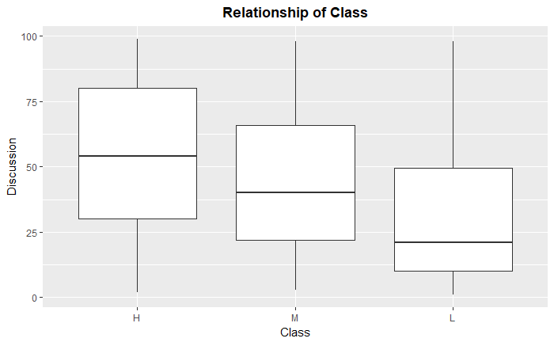

```r
ggplot(data = E, aes(x = Class, y = Discussion)) + geom_boxplot()+ ggtitle("Relationship of Class") +theme(plot.title = element_text(hjust = 0.5, lineheight = 0.8, face = "bold"))
```

# The higher class the higher times of discussion

# Gender and the numerial features

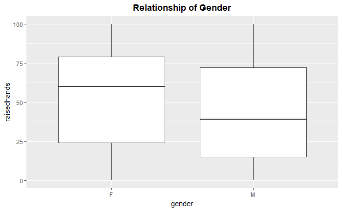

```r
ggplot(data = E, aes(x = gender, y = raisedhands)) + geom_boxplot()+ ggtitle("Relationship of Gender") +theme(plot.title = element_text(hjust = 0.5, lineheight = 0.8, face = "bold"))
```

# Girls have more hand raises

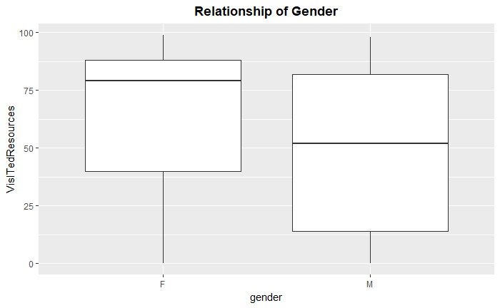

```r
ggplot(data = E, aes(x = gender, y = VisITedResources)) + geom_boxplot()+ ggtitle("Relationship of Gender") +theme(plot.title = element_text(hjust = 0.5, lineheight = 0.8, face = "bold"))
```

# Girls visit more resources

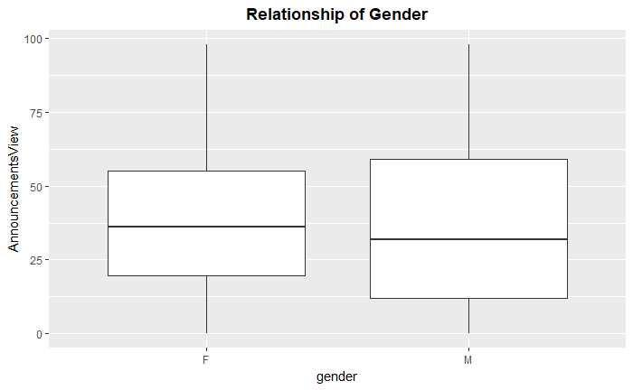

```r
ggplot(data = E, aes(x = gender, y = AnnouncementsView)) + geom_boxplot()+ ggtitle("Relationship of Gender") +theme(plot.title = element_text(hjust = 0.5, lineheight = 0.8, face = "bold"))
```

# Girls view more announcements, but the differences are not very obvious.

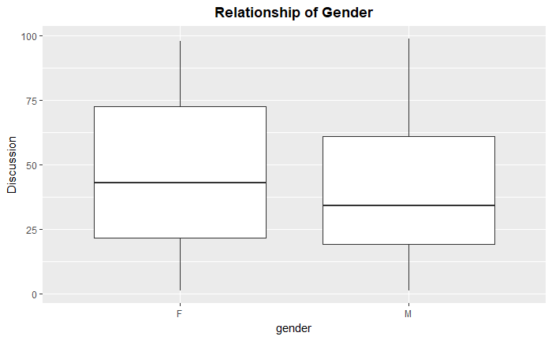

```r
ggplot(data = E, aes(x = gender, y = Discussion)) + geom_boxplot()+ ggtitle("Relationship of Gender") +theme(plot.title = element_text(hjust = 0.5, lineheight = 0.8, face = "bold"))
```